# PRABAL GHOSH WORKSHOP-1 R Notebook

```r
# plot(cars)
```

# LESSION-1

## Exercise 1: Simple Calculations

```r
# 31 * 78
31 * 78
```

```
[1] 2418
```

```r
# 697 / 41
697 / 41
```

```
[1] 17
```

```r
# Assign the value of 39 to x
# Assign the value of 22 to y
x<-39
x
```

```
[1] 39
```

```r
y<-22
y
```

```
[1] 22
```

```r
# Make z the value of x - y
z<- x-y
print(z)
```

```
[1] 17
```

Calculate the square root of 2345, and perform a log2 transformation on the result

```r
sqrt(2345)
```

```
[1] 48.4252
```

```r
log_2_value=log(sqrt(2345), base=exp(2))
print(log_2_value)
```

```
[1] 1.94001
```

## Exercise 2: Working with Vectors

##### Create a vector called vec1 containing the numbers 2,5,8,12 and 16

##### Use [lower]:[upper] notation to make a second vector called vec2 containing the numbers 5 to 9

##### Subtract vec2 from vec1 and look at the result

##### Use seq() to make a vector of 100 values starting at 2 and increasing by 3 each time and store it in a new variable

##### Extract the values at positions 5,10,15 and 20 in the vector of 100 values you made

##### Extract the values at positions 10 to 30 in the vector of 100 values you made

```r
# Create a vector called vec1 containing the numbers 2,5,8,12 and 16
vec1<- c(2,5,8,12,16)
vec1
```

```
[1]  2  5  8 12 16
```

```r
# Use [lower]:[upper] notation to make a second vector called vec2 containing the numbers 5 to 9
vec2<- 5:9
vec2
```

```
[1] 5 6 7 8 9
```

```r
# Subtract vec2 from vec1 and look at the result
vec1-vec2
```

```
[1] -3 -1  1  4  7
```

```r
# Use seq() to make a vector of 100 values starting at 2 and increasing by 3 each time and store it in a new variable

# seq1=seq(2, 100, by = 3)
# seq1

my_vector <- seq(from = 2, by = 3, length.out = 100)
my_vector
```

```
  [1]   2   5   8  11  14  17  20  23  26  29  32  35  38  41  44  47  50  53  56  59  62  65  68  71  74  77  80  83  86  89  92  95  98
 [34] 101 104 107 110 113 116 119 122 125 128 131 134 137 140 143 146 149 152 155 158 161 164 167 170 173 176 179 182 185 188 191 194 197
 [67] 200 203 206 209 212 215 218 221 224 227 230 233 236 239 242 245 248 251 254 257 260 263 266 269 272 275 278 281 284 287 290 293 296
[100] 299
```

```r
# Extract the values at positions 5,10,15 and 20 in the vector of 100 values you made
my_vector[c(5,10,15,20)]
```

```
[1] 14 29 44 59
```

```r
# Extract the values at positions 10 to 30 in the vector of 100 values you made
my_vector[10:30]
```

```
 [1] 29 32 35 38 41 44 47 50 53 56 59 62 65 68 71 74 77 80 83 86 89
```

##Exercise 3: Working with Vectors

##### Use the accessor $ to extract the state abbreviations and assign them to the object a. What is the class of this object?

##### Now use the square brackets to extract the state abbreviations and assign them to the object b. Use the identical function to determine if a and b are the same.

##### The function table takes a vector and returns the frequency of each element. You can quickly see how many states are in each region by applying this function. Use this function in one line of code to create a table of states per region.

```r
library("dplyr")
library(datasets)
data(murders)
class(murders)
```

```
[1] "data.frame"
```

```r
# Extract state abbreviations and assign to object 'a'
a <- murders$abb

# Determine the class of object 'a'
class(a)
```

```
[1] "character"
```

```r
# Extract state abbreviations using square brackets and assign to object 'b'
b <- murders["abb"]
b
```

| abb |
| --- |
| AL |
| AK |
| AZ |
| AR |
| CA |
| CO |
| CT |
| DE |
| DC |
| FL |

[output cut: 41 more lines]

```r
# Check if 'a' and 'b' are identical
identical(a, b)
```

```
[1] FALSE
```

```r
# Create a table of states per region
table(murders$region)
```

```
    Northeast         South North Central          West
            9            17            12            13
```

```r
head(murders,5)
```

|  | state | abb | region | population | total |
| --- | --- | --- | --- | --- | --- |
| 1 | Alabama | AL | South | 4779736 | 135 |
| 2 | Alaska | AK | West | 710231 | 19 |
| 3 | Arizona | AZ | West | 6392017 | 232 |
| 4 | Arkansas | AR | South | 2915918 | 93 |
| 5 | California | CA | West | 37253956 | 1257 |

```r
murders
```

| state | abb | region | population | total |
| --- | --- | --- | --- | --- |
| Alabama | AL | South | 4779736 | 135 |
| Alaska | AK | West | 710231 | 19 |
| Arizona | AZ | West | 6392017 | 232 |
| Arkansas | AR | South | 2915918 | 93 |
| California | CA | West | 37253956 | 1257 |
| Colorado | CO | West | 5029196 | 65 |
| Connecticut | CT | Northeast | 3574097 | 97 |
| Delaware | DE | South | 897934 | 38 |
| District of Columbia | DC | South | 601723 | 99 |
| Florida | FL | South | 19687653 | 669 |

[output cut: 41 more lines]

## Exercise 4: Reading in data from a file

##### Set your working directory to where the data files are stored. Make sure that the folder of data files has been unzipped. e.g. setwd(“D:/Data_folder”)

##### 4a

##### Read the file ‘small_file.txt’ into a new data structure. This is a tab delimited file so you should use read.delim(). Remember to assign a name to the data that you read in using the assignment operator, e.g.

##### my.small.file <- read.delim(“small_file.txt”)

##### View the data set to check that it has imported correctly.

##### 4b

##### Read the file ‘Child_Variants.csv’ into a new data structure. This is a comma separated file so you should use read.csv(). Again, remember to assign a name to the data when you import it.

##### Use head and View to look at the data set to check that it has imported correctly.

##### Calculate the mean of the column named MutantReadPercent. Think about how you are going to access a single column first (probably by using the $ notation), then once you can access the data pass it to the mean function.

```r
# Set your working directory to where the data files are stored. Make sure that
# the folder of data files has been unzipped. e.g. setwd("D:/Data_folder")

# setwd("C:/Users/praba/Desktop/uca1/M1/R programming/claas lab1 -lecture-3")


# 4a
# Read the file ‘small_file.txt’ into a new data structure. This is a tab delimited file so you should use read.delim(). Remember to assign a name to the data that you read in using the assignment operator, e.g.
# my.small.file <- read.delim(“small_file.txt”)
# View the data set to check that it has imported correctly.

data_small <- read.delim('C://Users//praba//Desktop//uca1//M1//R programming//claas lab1 -lecture-3//small_file.txt',header=FALSE, stringsAsFactors=FALSE)
head(data_small, 5)
```

|  | V1 | V2 | V3 |
| --- | --- | --- | --- |
| 1 | Sample | Length | Category |
| 2 | x_1 | 45 | A |
| 3 | x_2 | 82 | B |
| 4 | x_3 | 81 | C |
| 5 | x_4 | 56 | D |

```r
# View(data_small)



# 4b
# Read the file ‘Child_Variants.csv’ into a new data structure. This is a comma separated file so you should use read.csv(). Again, remember to assign a name to the data when you import it.
# Use head and View to look at the data set to check that it has imported correctly.
# Calculate the mean of the column named MutantReadPercent. Think about how you are going to access a single column first (probably by using the $ notation), then once you can access the data pass it to the mean function.

#Read the file ‘Child_Variants.csv’ into a new data structure.
data_childvariant<-read.csv("C://Users//praba//Desktop//uca1//M1//R programming//claas lab1 -lecture-3//Child_Variants.csv")
head(data_childvariant,3)
```

|  | CHR | POS | dbSNP | REF | ALT | QUAL | GENE | ENST | MutantReads | COVERAGE | MutantReadPercent |
| --- | --- | --- | --- | --- | --- | --- | --- | --- | --- | --- | --- |
| 1 | 1 | 69270 | . | A | G | 16 | OR4F5 | ENST00000335137 | 3 | 4 | 75 |
| 2 | 1 | 69511 | rs75062661 | A | G | 200 | OR4F5 | ENST00000335137 | 24 | 27 | 88 |
| 3 | 1 | 69761 | . | A | T | 200 | OR4F5 | ENST00000335137 | 8 | 8 | 100 |

```r
# View(data_childvariant)


#Calculate the mean of the column named MutantReadPercent
mean(data_childvariant$MutantReadPercent)
```

```
[1] 59.88219
```

##Exercise 5:

##### Using the dataset murder:

##### A. Create a histogram of the state populations.

##### B. Generate boxplots of the state populations by region.

```r
# Using the dataset murder:


data4 <- read.csv('C:\\Users\\praba\\Desktop\\uca1\\M1\\R programming\\claas lab1 -lecture-3\\Child_Variants.csv')
head(data4)
```

|  | CHR | POS | dbSNP | REF | ALT | QUAL | GENE | ENST | MutantReads | COVERAGE | MutantReadPercent |
| --- | --- | --- | --- | --- | --- | --- | --- | --- | --- | --- | --- |
| 1 | 1 | 69270 | . | A | G | 16 | OR4F5 | ENST00000335137 | 3 | 4 | 75 |
| 2 | 1 | 69511 | rs75062661 | A | G | 200 | OR4F5 | ENST00000335137 | 24 | 27 | 88 |
| 3 | 1 | 69761 | . | A | T | 200 | OR4F5 | ENST00000335137 | 8 | 8 | 100 |
| 4 | 1 | 69897 | rs75758884 | T | C | 59 | OR4F5 | ENST00000335137 | 3 | 3 | 100 |
| 5 | 1 | 877831 | rs6672356 | T | C | 200 | SAMD11 | ENST00000342066 | 10 | 11 | 90 |
| 6 | 1 | 881627 | rs2272757 | G | A | 200 | NOC2L | ENST00000327044 | 52 | 56 | 92 |

```r
mean(data4$MutantReadPercent)
```

```
[1] 59.88219
```

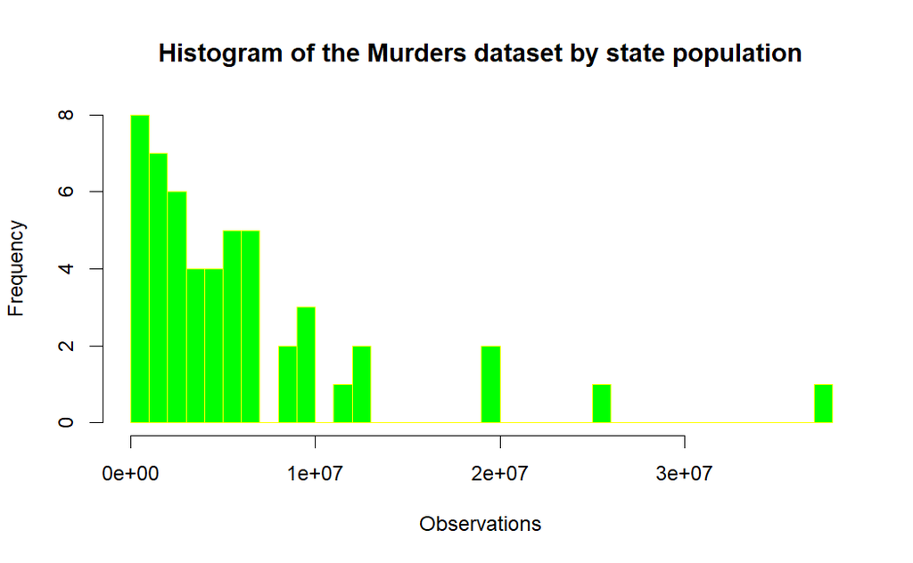

```r
# A. Create a histogram of the state populations.
hist(murders$population,
     breaks=50,
     main = "Histogram of the Murders dataset by state population",
     xlab = "Observations",
     ylab = "Frequency",
     col = "green",
     border = "yellow",)
```

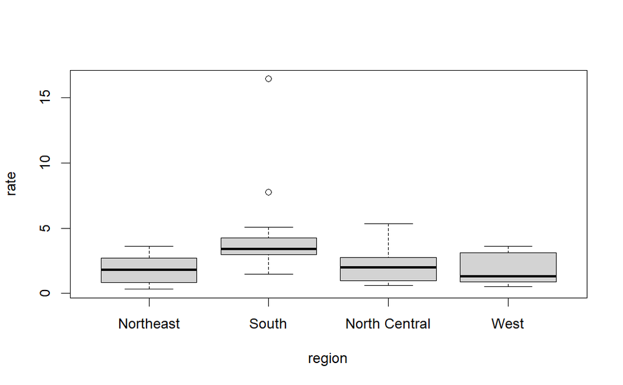

```r
# B. Generate boxplots of the state populations by region.
murders$rate<- with(murders,total/population * 100000)

boxplot(rate~region, data = murders)
```

```r
NA
NA
```

## Exercise 6: basic plots

##### Read in the file ‘brain_bodyweight.txt’. This is a tab delimited file so you can use read.delim(). The first column contains species names, not data, so use row.names=1 to set these up correctly in your data frame.

##### Log transform the data (base 2).

##### Create a scatterplot with default parameters with the log transformed data.

```r
# Read in the file ‘brain_bodyweight.txt’. This is a tab delimited file so you can use read.delim(). The first column contains species names, not data, so use row.names=1 to set these up correctly in your data frame.

# Log transform the data (base 2).

# Create a scatterplot with default parameters with the log transformed data.

# setwd("C:/Users/praba/Desktop/uca1/M1/R programming/claas lab1 -lecture-3")
data_brain<- read.delim("C://Users//praba//Desktop//uca1//M1//R programming//claas lab1 -lecture-3//brain_bodyweight.txt",row.names=1 )
head(data_brain)
```

|  | Body.weight..kg. | Brain.weight..g. |
| --- | --- | --- |
| Cow | 465.00 | 423.0 |
| Grey Wolf | 36.33 | 119.5 |
| Goat | 27.66 | 115.0 |
| Guinea Pig | 1.04 | 5.5 |
| Diplodocus | 11700.00 | 50.0 |
| Asian Elephant | 2547.00 | 4603.0 |

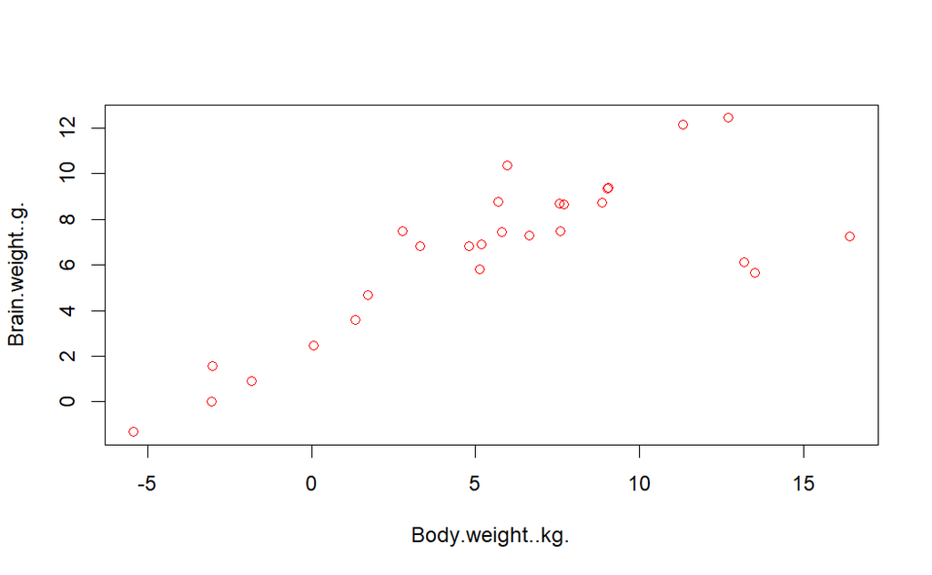

```r
log_1<-log2(data_brain)

plot(log_1,col='red')
```

## Exercise 7:

Multiplication Table: print the multiplication table of a number (entered by the user) from 1 to 10.

```r
# Hints:
# Here, we ask the user for a number which is stored in num variable.
# Then, the for loop is iterated 10 times from i equals to 1 to i equals to 10.


multip1<- function(x){

  for(i in 1:10){
    s=x*i
    cat(x,"*",i,"=",s,"\n")
    # print(paste(x,"*",i,"=",s))
  }

}
var1 = as.integer(readline(prompt = "Enter your number : "))
7
value<- multip1(var1)
```

```
7 * 1 = 7
7 * 2 = 14
7 * 3 = 21
7 * 4 = 28
7 * 5 = 35
7 * 6 = 42
7 * 7 = 49
7 * 8 = 56
7 * 9 = 63
7 * 10 = 70
```

```r
multip1<- function(x){
  list1<-list()
  for(i in 1:10){
    s=x*i
    list1[[i]]=s
  }

  return(list1)
}
value1<- multip1(7)
print(value1)
```

```
[[1]]
[1] 7

[[2]]
[1] 14

[[3]]
[1] 21

[[4]]
[1] 28

[[5]]
[1] 35

[[6]]
[1] 42

[[7]]
[1] 49

[[8]]
[1] 56

[[9]]
[1] 63

[[10]]
[1] 70
```

## Exercise 8:

Write a program to check if the input number is prime or not

```r
num <- as.integer(readline(prompt='please enter a number to check that its prime or not : '))
17
eras <- function(num){
  if(num < 2) {
    return(FALSE)
  }else{
    candidates <- 1:num
    candidates[1] <- 0
    for(i in 2:ceiling(sqrt(num))) {
      if(candidates[i] > 0) {
        if(floor(num/i) == num/i) {
          return(FALSE)
        }
        for(j in candidates[i:floor(num/i)]) {
          if(j > 0) {
            candidates[i*j] <- 0
          }
        }
      }
    }
  }
  return(TRUE)
}
if(eras(num)) {
  print(paste(num, ' is prime.'))
}else{
  print(paste(num, ' is not prime.'))
}
```

```
[1] "17  is prime."
```

# LESSION-2

## Question 2: Fibonacci Sequence in R

```r
recur_fibo <- function(n) {
    if(n <= 1) {
        return(n)
    } else {
        return(recur_fibo(n-1) + recur_fibo(n-2))}}

n=as.integer(readline('What is the number of terms: '))
10
for(i in 0:(n-1)) {
        print(recur_fibo(i))}
```

```
[1] 0
[1] 1
[1] 1
[1] 2
[1] 3
[1] 5
[1] 8
[1] 13
[1] 21
[1] 34
```

## Exercise 3: Program to Find GCD

```r
find_gcd <- function(a, b) {
  if (a !=0 & b !=0){
    smaller <- min(a, b)
    gcd_result <- 1  # Initialize GCD to 1

    # Use a for loop to find the GCD
    for (i in 1:smaller) {
      if (a %% i == 0 && b %% i == 0) {
        gcd_result <- i  # Update GCD if i perfectly divides both a and b
      }
    }

    return(gcd_result)}
  return ("you should not insert 0 as input please insert again")

}


number1 <- as.integer(readline("Enter the first integer: "))
7
number2 <- as.integer(readline("Enter the second integer: "))
77

gcd_result <- find_gcd(number1, number2)
cat("The GCD of", number1, "and", number2, "is", gcd_result, "\n")
```

```
The GCD of 7 and 77 is 7
```

## Exercise 5:

```r
data("iris")
head(iris,5)
```

|  | Sepal.Length | Sepal.Width | Petal.Length | Petal.Width | Species |
| --- | --- | --- | --- | --- | --- |
| 1 | 5.1 | 3.5 | 1.4 | 0.2 | setosa |
| 2 | 4.9 | 3.0 | 1.4 | 0.2 | setosa |
| 3 | 4.7 | 3.2 | 1.3 | 0.2 | setosa |
| 4 | 4.6 | 3.1 | 1.5 | 0.2 | setosa |
| 5 | 5.0 | 3.6 | 1.4 | 0.2 | setosa |

```r
data1=iris
```

Question 1 Select the first three columns of the iris dataset using their column names. HINT: Use select().

```r
# install.packages("dplyr")
library(dplyr)
# select(data1,Sepal.Length,Sepal.Width,Petal.Length)
# select(data1,Sepal.Length:Petal.Length)
select(data1,1:3)
```

| Sepal.Length | Sepal.Width | Petal.Length |
| --- | --- | --- |
| 5.1 | 3.5 | 1.4 |
| 4.9 | 3.0 | 1.4 |
| 4.7 | 3.2 | 1.3 |
| 4.6 | 3.1 | 1.5 |
| 5.0 | 3.6 | 1.4 |
| 5.4 | 3.9 | 1.7 |
| 4.6 | 3.4 | 1.4 |
| 5.0 | 3.4 | 1.5 |
| 4.4 | 2.9 | 1.4 |
| 4.9 | 3.1 | 1.5 |

[output cut: 140 more lines]

Question 2# Select all the columns of the iris dataset except “Petal Width”. HINT: Use “-“.

```r
head(select(data1,-Petal.Width),6)
```

|  | Sepal.Length | Sepal.Width | Petal.Length | Species |
| --- | --- | --- | --- | --- |
| 1 | 5.1 | 3.5 | 1.4 | setosa |
| 2 | 4.9 | 3.0 | 1.4 | setosa |
| 3 | 4.7 | 3.2 | 1.3 | setosa |
| 4 | 4.6 | 3.1 | 1.5 | setosa |
| 5 | 5.0 | 3.6 | 1.4 | setosa |
| 6 | 5.4 | 3.9 | 1.7 | setosa |

Question 3 Select all columns of the iris dataset that start with the character string “P”.

```r
select (data1,starts_with("p"))
```

| Petal.Length | Petal.Width |
| --- | --- |
| 1.4 | 0.2 |
| 1.4 | 0.2 |
| 1.3 | 0.2 |
| 1.5 | 0.2 |
| 1.4 | 0.2 |
| 1.7 | 0.4 |
| 1.4 | 0.3 |
| 1.5 | 0.2 |
| 1.4 | 0.2 |
| 1.5 | 0.1 |

[output cut: 140 more lines]

Question 4 Filter the rows of the iris dataset for Sepal.Length >= 4.6 and Petal.Width >= 0.5.

```r
data1 %>% select(Petal.Length,Petal.Width) %>% filter(Petal.Length>1.5)
```

| Petal.Length | Petal.Width |
| --- | --- |
| 1.7 | 0.4 |
| 1.6 | 0.2 |
| 1.7 | 0.3 |
| 1.7 | 0.2 |
| 1.7 | 0.5 |
| 1.9 | 0.2 |
| 1.6 | 0.2 |
| 1.6 | 0.4 |
| 1.6 | 0.2 |
| 1.6 | 0.2 |

[output cut: 103 more lines]

Question 5 Pipe the iris data frame to the function that will select two columns (Sepal.Width and Sepal.Length). HINT: Use pipe operator.

```r
sepal_only <- iris %>% select(Sepal.Width, Sepal.Length)
head(sepal_only,3)
```

|  | Sepal.Width | Sepal.Length |
| --- | --- | --- |
| 1 | 3.5 | 5.1 |
| 2 | 3.0 | 4.9 |
| 3 | 3.2 | 4.7 |

Question 6 Arrange rows by a particular column, such as the Sepal.Width. HINT: Use arrange().

```r
arrange(data1,  Sepal.Width)
```

| Sepal.Length | Sepal.Width | Petal.Length | Petal.Width | Species |
| --- | --- | --- | --- | --- |
| 5.0 | 2.0 | 3.5 | 1.0 | versicolor |
| 6.0 | 2.2 | 4.0 | 1.0 | versicolor |
| 6.2 | 2.2 | 4.5 | 1.5 | versicolor |
| 6.0 | 2.2 | 5.0 | 1.5 | virginica |
| 4.5 | 2.3 | 1.3 | 0.3 | setosa |
| 5.5 | 2.3 | 4.0 | 1.3 | versicolor |
| 6.3 | 2.3 | 4.4 | 1.3 | versicolor |
| 5.0 | 2.3 | 3.3 | 1.0 | versicolor |
| 4.9 | 2.4 | 3.3 | 1.0 | versicolor |
| 5.5 | 2.4 | 3.8 | 1.1 | versicolor |

[output cut: 140 more lines]

Question 7 Select three columns from iris, arrange the rows by Sepal.Length, then arrange the rows by Sepal.Width.

```r
data1 %>% select(Sepal.Length,Sepal.Width,Species) %>%arrange(Sepal.Length,Sepal.Width)
```

| Sepal.Length | Sepal.Width | Species |
| --- | --- | --- |
| 4.3 | 3.0 | setosa |
| 4.4 | 2.9 | setosa |
| 4.4 | 3.0 | setosa |
| 4.4 | 3.2 | setosa |
| 4.5 | 2.3 | setosa |
| 4.6 | 3.1 | setosa |
| 4.6 | 3.2 | setosa |
| 4.6 | 3.4 | setosa |
| 4.6 | 3.6 | setosa |
| 4.7 | 3.2 | setosa |

[output cut: 140 more lines]

```r
NA
```

#### Question 8

Create a new column called proportion, which is the ratio of Sepal.Length to Sepal.Width. HINT: Use mutate().

```r
data1_modified <- mutate(data1, proportion = Sepal.Length / Sepal.Width)
data1_modified
```

| Sepal.Length | Sepal.Width | Petal.Length | Petal.Width | Species | proportion |
| --- | --- | --- | --- | --- | --- |
| 5.1 | 3.5 | 1.4 | 0.2 | setosa | 1.457143 |
| 4.9 | 3.0 | 1.4 | 0.2 | setosa | 1.633333 |
| 4.7 | 3.2 | 1.3 | 0.2 | setosa | 1.468750 |
| 4.6 | 3.1 | 1.5 | 0.2 | setosa | 1.483871 |
| 5.0 | 3.6 | 1.4 | 0.2 | setosa | 1.388889 |
| 5.4 | 3.9 | 1.7 | 0.4 | setosa | 1.384615 |
| 4.6 | 3.4 | 1.4 | 0.3 | setosa | 1.352941 |
| 5.0 | 3.4 | 1.5 | 0.2 | setosa | 1.470588 |
| 4.4 | 2.9 | 1.4 | 0.2 | setosa | 1.517241 |
| 4.9 | 3.1 | 1.5 | 0.1 | setosa | 1.580645 |

[output cut: 140 more lines]

Question 9 Compute the average number of Sepal.Length, apply the mean() function to the column Sepal.Length, and call the summary value “avg_slength”. HINT: Use summarize().

```r
data1  %>%group_by(Species)%>% summarize(avg_slength = mean(Sepal.Length))
```

| Species | avg_slength |
| --- | --- |
| setosa | 5.006 |
| versicolor | 5.936 |
| virginica | 6.588 |

```r
NA
```

## Exercise 6: Restructuring data into ‘tidy’ format

##### You have been provided with three CSV data files (tidy_data1.csv, tidy_data2.csv, tidy_data3.csv).

##### After loading each of the data files think about the following.

##### Which of the columns are annotations and which are measurements

##### How many different types of measurement are there?

##### Are all of the measurements of the same type in a single column?

##### Do any annotation columns contain multiple pieces of information which have been concatenated together and would benefit from being split apart?

##### Are any of the columns purely for annotation and might benefit from being split into another tibble to avoid duplication?

##### After tidying are there any NA values which should be removed?

```r
if (!requireNamespace("dplyr", quietly = TRUE)) {
  install.packages("dplyr")
}
```

```r
 library(dplyr)
```

```r
library(tidyr)
```

```r
# setwd("C:/Users/praba/Desktop/uca1/M1/R programming/claas lab1 -lecture-3")
data_tidy_1 <- read.csv("C://Users//praba//Desktop//uca1//M1//R programming//claas lab1 -lecture-3//tidy_data1.csv")

data_tidy_2 <- read.csv("C://Users//praba//Desktop//uca1//M1//R programming//claas lab1 -lecture-3//tidy_data2.csv")

data_tidy_3 <- read.csv("C://Users//praba//Desktop//uca1//M1//R programming//claas lab1 -lecture-3//tidy_data3.csv")
```

```r
head(data_tidy_1,6)
```

|  | DMSO | TGX.221 | PI103 | Akt1 |
| --- | --- | --- | --- | --- |
| 1 | 144.43930 | 99.61073 | 41.95241 | 111.8013 |
| 2 | 135.71670 | 115.35760 | 57.46430 | 124.1805 |
| 3 | 57.88828 | 106.44840 | 41.01954 | 126.7738 |
| 4 | 66.71269 | 115.89830 | 63.12587 | 130.9577 |
| 5 | 73.36981 | 75.96729 | NA | 88.6273 |
| 6 | 83.43180 | NA | NA | 147.8813 |

```r
head(data_tidy_2,6)
```

|  | ID | Chr | Start | End | Strand | A | B | C | D | E |
| --- | --- | --- | --- | --- | --- | --- | --- | --- | --- | --- |
| 1 | ENSMUSG00000026034 | 1 | 58356743 | 58366480 | - | 0.40 | 0.26 | 0.24 | 1.04 | 0.74 |
| 2 | ENSMUSG00000059027 | 4 | 109150366 | 109155759 | - | 1.50 | 0.47 | 0.25 | 2.78 | 0.99 |
| 3 | ENSMUSG00000029625 | 5 | 145420751 | 145435567 | + | 0.98 | 0.42 | 1.01 | 0.82 | 1.26 |
| 4 | ENSMUSG00000030271 | 6 | 113292779 | 113299963 | + | 0.33 | 0.64 | 0.77 | 1.65 | 1.50 |
| 5 | ENSMUSG00000030530 | 7 | 80262709 | 80276275 | - | 0.75 | 0.32 | 0.47 | 0.49 | 0.30 |
| 6 | ENSMUSG00000030869 | 7 | 121877984 | 121892994 | - | 1.48 | 0.65 | 0.47 | 0.97 | 0.34 |

```r
head(data_tidy_3,6)
```

|  | Probe_ID | Symbol | WT_1 | WT_2 | WT_3 | KO_1 | KO_2 | KO_3 |
| --- | --- | --- | --- | --- | --- | --- | --- | --- |
| 1 | 214956_at | AAK1 | 154 | 198 | 162 | 322 | 198 | 329 |
| 2 | 208636_at | ACTN1 | 133 | 187 | 162 | 324 | 240 | 280 |
| 3 | 201752_s_at | ADD3 | 170 | 160 | 155 | 230 | 195 | 318 |
| 4 | 201792_at | AEBP1 | 198 | 168 | 149 | 308 | 229 | 332 |
| 5 | 1556212_x_at | AIG1 | 147 | 191 | 178 | 289 | 239 | 234 |
| 6 | 1552895_a_at | ANKRD30B | 149 | 132 | 187 | 230 | 283 | 262 |

### in data_tidy_1 ——> 4 different types of measurements

### in data_tidy_2—–> Columns A to E represent measurements while the other columns are atomic annotations.

### in data_tidy_3 —-> Columns WT_1 to KO_3 are measurements of two different genotypes with three replicates each

```r
str(data_tidy_1)   # Check the structure of the data
```

```
'data.frame':   17 obs. of  4 variables:
 $ DMSO   : num  144.4 135.7 57.9 66.7 73.4 ...
 $ TGX.221: num  99.6 115.4 106.4 115.9 76 ...
 $ PI103  : num  42 57.5 41 63.1 NA ...
 $ Akt1   : num  111.8 124.2 126.8 131 88.6 ...
```

```r
cat("\n")
```

```r
str(data_tidy_2)   # Check the structure of the data
```

```
'data.frame':   12 obs. of  10 variables:
 $ ID    : chr  "ENSMUSG00000026034" "ENSMUSG00000059027" "ENSMUSG00000029625" "ENSMUSG00000030271" ...
 $ Chr   : chr  "1" "4" "5" "6" ...
 $ Start : int  58356743 109150366 145420751 113292779 80262709 121877984 3457108 107416911 108338048 65865318 ...
 $ End   : int  58366480 109155759 145435567 113299963 80276275 121892994 3467680 107426513 108348632 65875133 ...
 $ Strand: chr  "-" "-" "+" "+" ...
 $ A     : num  0.4 1.5 0.98 0.33 0.75 1.48 1.18 0.33 1.42 2.09 ...
 $ B     : num  0.26 0.47 0.42 0.64 0.32 0.65 0.43 0.67 0.43 0.7 ...
 $ C     : num  0.24 0.25 1.01 0.77 0.47 0.47 0.46 0.65 0.41 0.81 ...
 $ D     : num  1.04 2.78 0.82 1.65 0.49 0.97 1.39 3.24 1.12 2.82 ...
 $ E     : num  0.74 0.99 1.26 1.5 0.3 0.34 0.77 1.94 2.62 1.42 ...
```

```r
cat("\n")
```

```r
str(data_tidy_3)   # Check the structure of the data
```

```
'data.frame':   174 obs. of  8 variables:
 $ Probe_ID: chr  "214956_at" "208636_at" "201752_s_at" "201792_at" ...
 $ Symbol  : chr  "AAK1" "ACTN1" "ADD3" "AEBP1" ...
 $ WT_1    : int  154 133 170 198 147 149 105 104 147 133 ...
 $ WT_2    : int  198 187 160 168 191 132 104 196 185 140 ...
 $ WT_3    : int  162 162 155 149 178 187 156 198 109 145 ...
 $ KO_1    : int  322 324 230 308 289 230 210 290 205 274 ...
 $ KO_2    : int  198 240 195 229 239 283 259 217 244 270 ...
 $ KO_3    : int  329 280 318 332 234 262 324 212 332 180 ...
```

```r
data_tidy_1 %>%
  mutate(id = row_number()) %>%
  pivot_longer(cols=1:4, names_to='measurement', values_to='values') %>%
  drop_na
```

| id | measurement | values |
| --- | --- | --- |
| 1 | DMSO | 144.43930 |
| 1 | TGX.221 | 99.61073 |
| 1 | PI103 | 41.95241 |
| 1 | Akt1 | 111.80130 |
| 2 | DMSO | 135.71670 |
| 2 | TGX.221 | 115.35760 |
| 2 | PI103 | 57.46430 |
| 2 | Akt1 | 124.18050 |
| 3 | DMSO | 57.88828 |
| 3 | TGX.221 | 106.44840 |

[output cut: 25 more lines]

```r
data_tidy_2 %>%
  pivot_longer(cols=A:E, names_to='measurement', values_to='values') %>%
  drop_na %>%
  head
```

| ID | Chr | Start | End | Strand | measurement | values |
| --- | --- | --- | --- | --- | --- | --- |
| ENSMUSG00000026034 | 1 | 58356743 | 58366480 | - | A | 0.40 |
| ENSMUSG00000026034 | 1 | 58356743 | 58366480 | - | B | 0.26 |
| ENSMUSG00000026034 | 1 | 58356743 | 58366480 | - | C | 0.24 |
| ENSMUSG00000026034 | 1 | 58356743 | 58366480 | - | D | 1.04 |
| ENSMUSG00000026034 | 1 | 58356743 | 58366480 | - | E | 0.74 |
| ENSMUSG00000059027 | 4 | 109150366 | 109155759 | - | A | 1.50 |

```r
data_tidy_3 %>%
  pivot_longer(cols=WT_1:KO_3, names_to='sample', values_to='values') %>%
  separate(sample, into=c('genotype', 'replicate'), convert=TRUE, sep='_') %>%
  separate(Probe_ID, into=c('ID', 'Something'), convert=TRUE, sep='_', extra='merge') %>%
  head
```

| ID | Something | Symbol | genotype | replicate | values |
| --- | --- | --- | --- | --- | --- |
| 214956 | at | AAK1 | WT | 1 | 154 |
| 214956 | at | AAK1 | WT | 2 | 198 |
| 214956 | at | AAK1 | WT | 3 | 162 |
| 214956 | at | AAK1 | KO | 1 | 322 |
| 214956 | at | AAK1 | KO | 2 | 198 |
| 214956 | at | AAK1 | KO | 3 | 329 |

## Exercise 7:

##### 1.Use the airquality dataset from base

```r
# Load the airquality dataset
data("airquality")
```

##### 2.Compute the percentage p_na of missing values in a column

```r
percentage_missing_column <- sapply(airquality, function(column) mean(is.na(column)) * 100)
percentage_missing_column
```

```
    Ozone   Solar.R      Wind      Temp     Month       Day
24.183007  4.575163  0.000000  0.000000  0.000000  0.000000
```

```r
# Ozone and  Solar.R cloumn has NA values
```

### 3.If p_na > 0,05  delete the column

### 4.If p_na <= 0,05  replace the missing values by 0 or by the mean of the column, depending on a variable “type_na”

```r
percentage_missing_column<- sapply(airquality, function(column) mean(is.na(column)) * 100)

for (col_name in names(percentage_missing_column)) {
  p_na <- percentage_missing_column[col_name]

  if (p_na > 5) {
    airquality[[col_name]] <- NULL
  } else {
    if (is.numeric(airquality[[col_name]])) {
      airquality[is.na(airquality[[col_name]]), col_name] <- mean(airquality[[col_name]], na.rm = TRUE)
    } else {
      airquality[is.na(airquality[[col_name]]), col_name] <- 0
    }
  }
}


head(airquality)
```

|  | Solar.R | Wind | Temp | Month | Day |
| --- | --- | --- | --- | --- | --- |
| 1 | 190.0000 | 7.4 | 67 | 5 | 1 |
| 2 | 118.0000 | 8.0 | 72 | 5 | 2 |
| 3 | 149.0000 | 12.6 | 74 | 5 | 3 |
| 4 | 313.0000 | 11.5 | 62 | 5 | 4 |
| 5 | 185.9315 | 14.3 | 56 | 5 | 5 |
| 6 | 185.9315 | 14.9 | 66 | 5 | 6 |